# Práctica 1: Hechos estilizados sobre el comportamiento del precio y el rendimiento de los activos

Author

Alan Jesús Hernández Soto

Published

August 31, 2026

# 1. Introducción

Se seleccionara 3 activos que coticen en una bolsa distinta a la BMV calculando su rendimineto como base para analizar si se cumplen los 4 hechos estilizados los cuales son dependencia lineal debil, agrupamiento de volatilidad, colas pesadas y asímetria. Apartir de esto con asistencia de IA se retroalimentara y buscara modificar el analisis realizado para buscar una conclusión concisa.

Los activos a utilizar son: - NVDA: NVIDIA Corporation - AMD: Advanced Micro Devices, Inc. - AVGO: Broadcom Inc.

Se utiliza esta selección ya que pertenecen a la Industria de Semiconductores para Inteligencia Artificial que esta en auge esta última decada lo cual puede brindar un analisis interesante sobre 3 pilares del mercado.

# 2. Análisis de los hechos estilizados

## Obtención de Precios

**Mostrar código**

```r
library(quantmod)
```

**Mostrar código**

```r
library(moments)
ticker <- c('NVDA', 'AVGO', 'AMD')

getSymbols(
  ticker,
  src='yahoo',
  from='2022-01-01'
)
```

```
[1] "NVDA" "AVGO" "AMD"
```

**Mostrar código**

```r
price <- do.call(merge, lapply(ticker, function(t) Ad(get(t))))
colnames(price) <- ticker

head(price)
```

```
               NVDA     AVGO    AMD
2022-01-03 30.02614 61.21919 150.24
2022-01-04 29.19776 61.92064 144.42
2022-01-05 27.51707 59.34382 136.15
2022-01-06 28.08926 58.79284 136.23
2022-01-07 27.16119 57.14266 132.00
2022-01-10 27.31371 57.32817 132.00
```

## Gráfico de Precios

**Mostrar código**

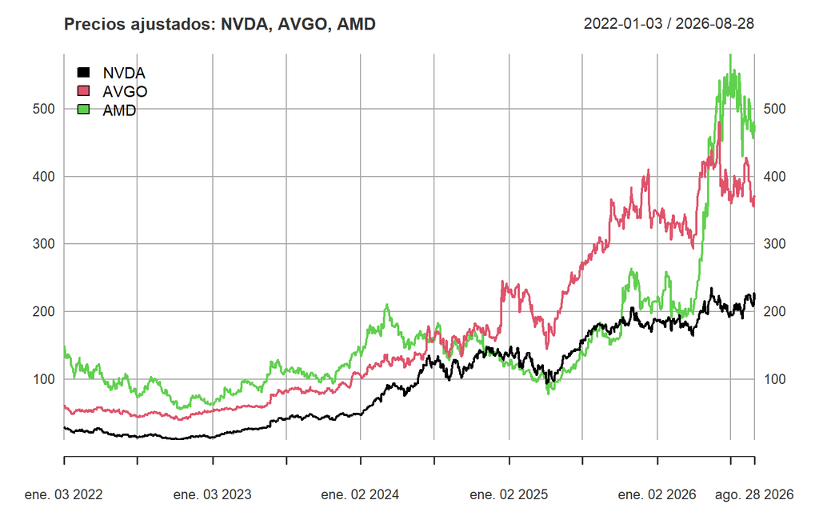

```r
plot(price, main = "Precios ajustados: NVDA, AVGO, AMD",
     legend.loc = "topleft")
```

**Mostrar código**

```r
class(price)
```

```
[1] "xts" "zoo"
```

## Obtención de Rendimiento

**Mostrar código**

```r
simple_return <- na.omit(do.call(merge, lapply(price, function(x) dailyReturn(x, type = "arithmetic"))))
log_return    <- na.omit(do.call(merge, lapply(price, function(x) dailyReturn(x, type = "log"))))

colnames(simple_return) <- ticker
colnames(log_return)    <- ticker

head(cbind(simple_return, log_return))
```

```
                   NVDA         AVGO           AMD       NVDA.1       AVGO.1
2022-01-03  0.000000000  0.000000000  0.0000000000  0.000000000  0.000000000
2022-01-04 -0.027588771  0.011457952 -0.0387380665 -0.027976488  0.011392807
2022-01-05 -0.057562189 -0.041614766 -0.0572635672 -0.059285345 -0.042505459
2022-01-06  0.020793975 -0.009284532  0.0005876007  0.020580732 -0.009327902
2022-01-07 -0.033040030 -0.028067716 -0.0310503990 -0.033598181 -0.028469144
2022-01-10  0.005615336  0.003246347  0.0000000000  0.005599629  0.003241089
                   AMD.1
2022-01-03  0.0000000000
2022-01-04 -0.0395083437
2022-01-05 -0.0589685341
2022-01-06  0.0005874281
2022-01-07 -0.0315426798
2022-01-10  0.0000000000
```

## Gráfico de Rendimientos Logaritmico

**Mostrar código**

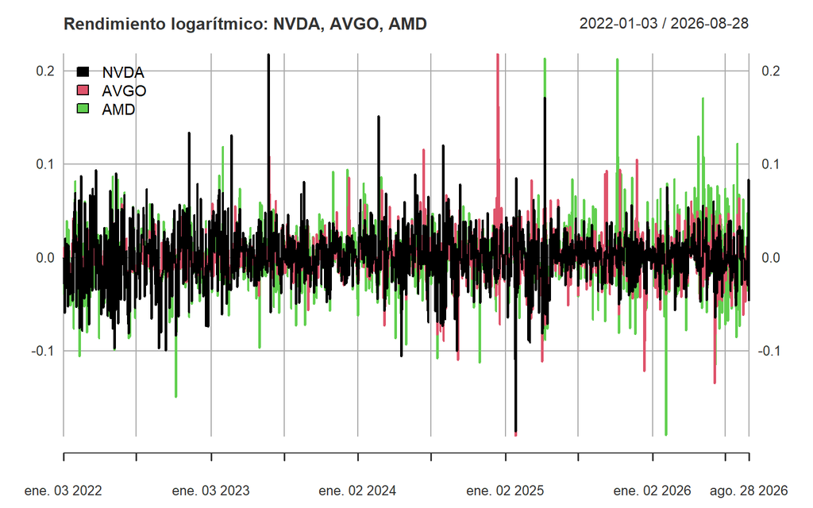

```r
plot(log_return, main = "Rendimiento logarítmico: NVDA, AVGO, AMD",
     legend.loc = "topleft")
```